# Assignment3_Wanzhen Li

```python
import pandas as pd
import matplotlib.pyplot as plt
import numpy as np
import seaborn as sns
```

Part I:Random Forest Model A. Read the dataset telecom_users.csv into Python.

```python
tele_users = pd.read_csv("telecom_users.csv")
tele_users
```

|  | Unnamed: 0 | customerID | gender | SeniorCitizen | Partner | Dependents | tenure | PhoneService | MultipleLines | InternetService | ... | DeviceProtection | TechSupport | StreamingTV | StreamingMovies | Contract | PaperlessBilling | PaymentMethod | MonthlyCharges | TotalCharges | Churn |
| --- | --- | --- | --- | --- | --- | --- | --- | --- | --- | --- | --- | --- | --- | --- | --- | --- | --- | --- | --- | --- | --- |
| 0 | 1869 | 7010-BRBUU | Male | 0 | Yes | Yes | 72 | Yes | Yes | No | ... | No internet service | No internet service | No internet service | No internet service | Two year | No | Credit card (automatic) | 24.10 | 1734.65 | No |
| 1 | 4528 | 9688-YGXVR | Female | 0 | No | No | 44 | Yes | No | Fiber optic | ... | Yes | No | Yes | No | Month-to-month | Yes | Credit card (automatic) | 88.15 | 3973.2 | No |
| 2 | 6344 | 9286-DOJGF | Female | 1 | Yes | No | 38 | Yes | Yes | Fiber optic | ... | No | No | No | No | Month-to-month | Yes | Bank transfer (automatic) | 74.95 | 2869.85 | Yes |
| 3 | 6739 | 6994-KERXL | Male | 0 | No | No | 4 | Yes | No | DSL | ... | No | No | No | Yes | Month-to-month | Yes | Electronic check | 55.90 | 238.5 | No |
| 4 | 432 | 2181-UAESM | Male | 0 | No | No | 2 | Yes | No | DSL | ... | Yes | No | No | No | Month-to-month | No | Electronic check | 53.45 | 119.5 | No |
| ... | ... | ... | ... | ... | ... | ... | ... | ... | ... | ... | ... | ... | ... | ... | ... | ... | ... | ... | ... | ... | ... |
| 5981 | 3772 | 0684-AOSIH | Male | 0 | Yes | No | 1 | Yes | No | Fiber optic | ... | No | No | Yes | Yes | Month-to-month | Yes | Electronic check | 95.00 | 95 | Yes |
| 5982 | 5191 | 5982-PSMKW | Female | 0 | Yes | Yes | 23 | Yes | Yes | DSL | ... | Yes | Yes | Yes | Yes | Two year | Yes | Credit card (automatic) | 91.10 | 2198.3 | No |
| 5983 | 5226 | 8044-BGWPI | Male | 0 | Yes | Yes | 12 | Yes | No | No | ... | No internet service | No internet service | No internet service | No internet service | Month-to-month | Yes | Electronic check | 21.15 | 306.05 | No |
| 5984 | 5390 | 7450-NWRTR | Male | 1 | No | No | 12 | Yes | Yes | Fiber optic | ... | Yes | No | Yes | Yes | Month-to-month | Yes | Electronic check | 99.45 | 1200.15 | Yes |
| 5985 | 860 | 4795-UXVCJ | Male | 0 | No | No | 26 | Yes | No | No | ... | No internet service | No internet service | No internet service | No internet service | One year | No | Credit card (automatic) | 19.80 | 457.3 | No |

5986 rows × 22 columns

B. Categorical:customerID,gender,Partner,Dependents,PhoneService,MultipleLines,InternetService,OnlineSecurity,OnlineBackup,DeviceProtection,TechSupport,StreamingTV,StreamingMovies,Contract,PaperlessBilling,PaymentMethod,Churn Numerical:Unnamed,SeniorCitizen,tenure,MonthlyCharges

a.Yes,I will convert them into dummy. Because the logistic regression cannot understand categorical variables.It can be built only if they are converted into dummies.

```python
tele_users.info()
```

```
<class 'pandas.core.frame.DataFrame'>
RangeIndex: 5986 entries, 0 to 5985
Data columns (total 22 columns):
 #   Column            Non-Null Count  Dtype
---  ------            --------------  -----
 0   Unnamed: 0        5986 non-null   int64
 1   customerID        5986 non-null   object
 2   gender            5986 non-null   object
 3   SeniorCitizen     5986 non-null   int64
 4   Partner           5986 non-null   object
 5   Dependents        5986 non-null   object
 6   tenure            5986 non-null   int64
 7   PhoneService      5986 non-null   object
 8   MultipleLines     5986 non-null   object
 9   InternetService   5986 non-null   object
 10  OnlineSecurity    5986 non-null   object
 11  OnlineBackup      5986 non-null   object
 12  DeviceProtection  5986 non-null   object
 13  TechSupport       5986 non-null   object
 14  StreamingTV       5986 non-null   object
 15  StreamingMovies   5986 non-null   object
 16  Contract          5986 non-null   object
 17  PaperlessBilling  5986 non-null   object
 18  PaymentMethod     5986 non-null   object
 19  MonthlyCharges    5986 non-null   float64
 20  TotalCharges      5986 non-null   object
 21  Churn             5986 non-null   object
dtypes: float64(1), int64(3), object(18)
memory usage: 1.0+ MB
```

B. b.

```python
tele_users['gender'] = tele_users['gender'].map({'Male':0,'Female':1})
tele_users['Partner'] = tele_users['Partner'].map({'No':0,'Yes':1})
tele_users['Dependents'] = tele_users['Dependents'].map({'No':0,'Yes':1})
tele_users['PhoneService'] = tele_users['PhoneService'].map({'No':0,'Yes':1})
tele_users['MultipleLines'] = tele_users['MultipleLines'].map({'No':0,'Yes':1,'No phone service':2})
tele_users['OnlineSecurity'] = tele_users['OnlineSecurity'].map({'No':0,'Yes':1,'No internet service':2})
tele_users['OnlineBackup'] = tele_users['OnlineBackup'].map({'No':0,'Yes':1,'No internet service':2})
tele_users['DeviceProtection'] = tele_users['DeviceProtection'].map({'No':0,'Yes':1,'No internet service':2})
tele_users['TechSupport'] = tele_users['TechSupport'].map({'No':0,'Yes':1,'No internet service':2})
tele_users['StreamingTV'] = tele_users['StreamingTV'].map({'No':0,'Yes':1,'No internet service':2})
tele_users['StreamingMovies'] = tele_users['StreamingMovies'].map({'No':0,'Yes':1,'No internet service':2})
tele_users['PaperlessBilling'] = tele_users['PaperlessBilling'].map({'No':0,'Yes':1})
tele_users['InternetService'] = tele_users['InternetService'].map({'No':0,'DSL':1,'Fiber optic':2})
tele_users['Contract'] = tele_users['Contract'].map({'Month-to-month':0,'One year':1,'Two year':2})
tele_users['PaymentMethod'] = tele_users['PaymentMethod'].map({'Bank transfer (automatic)':0,'Credit card (automatic)':1,'Electronic check':2,'Mailed check':3})
tele_users['Churn'] = telecom_users['Churn'].map({'No':0,'Yes':1})
tele_users
```

|  | Unnamed: 0 | customerID | gender | SeniorCitizen | Partner | Dependents | tenure | PhoneService | MultipleLines | InternetService | ... | DeviceProtection | TechSupport | StreamingTV | StreamingMovies | Contract | PaperlessBilling | PaymentMethod | MonthlyCharges | TotalCharges | Churn |
| --- | --- | --- | --- | --- | --- | --- | --- | --- | --- | --- | --- | --- | --- | --- | --- | --- | --- | --- | --- | --- | --- |
| 0 | 1869 | 7010-BRBUU | 0 | 0 | 1 | 1 | 72 | 1 | 1 | 0 | ... | 2 | 2 | 2 | 2 | 2 | 0 | 1 | 24.10 | 1734.65 | 0 |
| 1 | 4528 | 9688-YGXVR | 1 | 0 | 0 | 0 | 44 | 1 | 0 | 2 | ... | 1 | 0 | 1 | 0 | 0 | 1 | 1 | 88.15 | 3973.2 | 0 |
| 2 | 6344 | 9286-DOJGF | 1 | 1 | 1 | 0 | 38 | 1 | 1 | 2 | ... | 0 | 0 | 0 | 0 | 0 | 1 | 0 | 74.95 | 2869.85 | 1 |
| 3 | 6739 | 6994-KERXL | 0 | 0 | 0 | 0 | 4 | 1 | 0 | 1 | ... | 0 | 0 | 0 | 1 | 0 | 1 | 2 | 55.90 | 238.5 | 0 |
| 4 | 432 | 2181-UAESM | 0 | 0 | 0 | 0 | 2 | 1 | 0 | 1 | ... | 1 | 0 | 0 | 0 | 0 | 0 | 2 | 53.45 | 119.5 | 0 |
| ... | ... | ... | ... | ... | ... | ... | ... | ... | ... | ... | ... | ... | ... | ... | ... | ... | ... | ... | ... | ... | ... |
| 5981 | 3772 | 0684-AOSIH | 0 | 0 | 1 | 0 | 1 | 1 | 0 | 2 | ... | 0 | 0 | 1 | 1 | 0 | 1 | 2 | 95.00 | 95 | 1 |
| 5982 | 5191 | 5982-PSMKW | 1 | 0 | 1 | 1 | 23 | 1 | 1 | 1 | ... | 1 | 1 | 1 | 1 | 2 | 1 | 1 | 91.10 | 2198.3 | 0 |
| 5983 | 5226 | 8044-BGWPI | 0 | 0 | 1 | 1 | 12 | 1 | 0 | 0 | ... | 2 | 2 | 2 | 2 | 0 | 1 | 2 | 21.15 | 306.05 | 0 |
| 5984 | 5390 | 7450-NWRTR | 0 | 1 | 0 | 0 | 12 | 1 | 1 | 2 | ... | 1 | 0 | 1 | 1 | 0 | 1 | 2 | 99.45 | 1200.15 | 1 |
| 5985 | 860 | 4795-UXVCJ | 0 | 0 | 0 | 0 | 26 | 1 | 0 | 0 | ... | 2 | 2 | 2 | 2 | 1 | 0 | 1 | 19.80 | 457.3 | 0 |

5986 rows × 22 columns

```python
tele_users2=tele_users.drop(['Unnamed: 0','customerID','TotalCharges'],axis=1)
tele_users2
```

|  | gender | SeniorCitizen | Partner | Dependents | tenure | PhoneService | MultipleLines | InternetService | OnlineSecurity | OnlineBackup | DeviceProtection | TechSupport | StreamingTV | StreamingMovies | Contract | PaperlessBilling | PaymentMethod | MonthlyCharges | Churn |
| --- | --- | --- | --- | --- | --- | --- | --- | --- | --- | --- | --- | --- | --- | --- | --- | --- | --- | --- | --- |
| 0 | 0 | 0 | 1 | 1 | 72 | 1 | 1 | 0 | 2 | 2 | 2 | 2 | 2 | 2 | 2 | 0 | 1 | 24.10 | 0 |
| 1 | 1 | 0 | 0 | 0 | 44 | 1 | 0 | 2 | 0 | 1 | 1 | 0 | 1 | 0 | 0 | 1 | 1 | 88.15 | 0 |
| 2 | 1 | 1 | 1 | 0 | 38 | 1 | 1 | 2 | 0 | 0 | 0 | 0 | 0 | 0 | 0 | 1 | 0 | 74.95 | 1 |
| 3 | 0 | 0 | 0 | 0 | 4 | 1 | 0 | 1 | 0 | 0 | 0 | 0 | 0 | 1 | 0 | 1 | 2 | 55.90 | 0 |
| 4 | 0 | 0 | 0 | 0 | 2 | 1 | 0 | 1 | 1 | 0 | 1 | 0 | 0 | 0 | 0 | 0 | 2 | 53.45 | 0 |
| ... | ... | ... | ... | ... | ... | ... | ... | ... | ... | ... | ... | ... | ... | ... | ... | ... | ... | ... | ... |
| 5981 | 0 | 0 | 1 | 0 | 1 | 1 | 0 | 2 | 1 | 0 | 0 | 0 | 1 | 1 | 0 | 1 | 2 | 95.00 | 1 |
| 5982 | 1 | 0 | 1 | 1 | 23 | 1 | 1 | 1 | 1 | 1 | 1 | 1 | 1 | 1 | 2 | 1 | 1 | 91.10 | 0 |
| 5983 | 0 | 0 | 1 | 1 | 12 | 1 | 0 | 0 | 2 | 2 | 2 | 2 | 2 | 2 | 0 | 1 | 2 | 21.15 | 0 |
| 5984 | 0 | 1 | 0 | 0 | 12 | 1 | 1 | 2 | 0 | 0 | 1 | 0 | 1 | 1 | 0 | 1 | 2 | 99.45 | 1 |
| 5985 | 0 | 0 | 0 | 0 | 26 | 1 | 0 | 0 | 2 | 2 | 2 | 2 | 2 | 2 | 1 | 0 | 1 | 19.80 | 0 |

5986 rows × 19 columns

C: I did it as above.

D:

```python
tele_users['Churn'].value_counts()
```

[output not shown]

```python
tele_users['Churn'].value_counts(normalize=True)
```

[output not shown]

The 1st function only count the number of each categories, while the 2nd one count the percentage of each categories, which provide us a better sense of the relative frequency of the dataset.In the column "Churn", we can easily find that "No" is the more common answer.

E. 654 is our class's number, I just use it to guarantee that this code could be run over and over again, and would give the same results every time.

```python
tele_users2.columns
```

```
Index(['gender', 'SeniorCitizen', 'Partner', 'Dependents', 'tenure',
       'PhoneService', 'MultipleLines', 'InternetService', 'OnlineSecurity',
       'OnlineBackup', 'DeviceProtection', 'TechSupport', 'StreamingTV',
       'StreamingMovies', 'Contract', 'PaperlessBilling', 'PaymentMethod',
       'MonthlyCharges', 'Churn'],
      dtype='object')
```

```python
from sklearn.model_selection import train_test_split
X = tele_users2[['gender', 'SeniorCitizen', 'Partner',
       'Dependents', 'tenure', 'PhoneService', 'MultipleLines',
       'InternetService', 'OnlineSecurity', 'OnlineBackup', 'DeviceProtection',
       'TechSupport', 'StreamingTV', 'StreamingMovies', 'Contract',
       'PaperlessBilling', 'PaymentMethod', 'MonthlyCharges']]
y = tele_users2['Churn']
X_train, X_test, y_train, y_test = train_test_split(X, y, test_size=0.4, random_state=654)
```

F.

```python
from sklearn.ensemble import RandomForestClassifier
clf=RandomForestClassifier()
clf.fit(X_train,y_train)
```

```
RandomForestClassifier()
```

```python
para_test = {
    'n_estimators': [50, 70, 100],
    'max_depth': [4, 6, 8],
    'max_features': [12, 14, 16], # max features should be lower than 17
    'min_samples_leaf': [6, 10, 14]
}
```

```python
from sklearn.model_selection import GridSearchCV
CV_rfc = GridSearchCV(estimator=clf, param_grid=para_test, cv= 5)
CV_rfc.fit(X_train, y_train)
print(CV_rfc.best_params_)
```

```
{'max_depth': 6, 'max_features': 14, 'min_samples_leaf': 10, 'n_estimators': 50}
```

```python
CV_rfc.best_score_
```

```
0.8017286466424661
```

```python
Rainf_clf=RandomForestClassifier(n_estimators=50, max_depth=6, max_features=14, min_samples_leaf=10, random_state=654)
Rainf_clf.fit(X_train,y_train)
```

```
RandomForestClassifier(max_depth=6, max_features=14, min_samples_leaf=10,
                       n_estimators=50, random_state=654)
```

G:

The higher the score, the more important the feature is. In this model, tenure and MonthlyCharges are mor important features than the otheres.

```python
feature_imp = pd.DataFrame(list(zip(Rainf_clf.feature_importances_, X_train)))
feature_imp.columns = ['feature importance', 'feature']
feature_imp = feature_imp_df.sort_values(by='feature importance', ascending=False)
feature_imp
```

[output not shown]

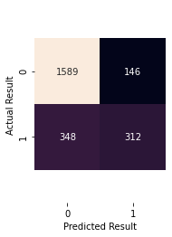

```python
%matplotlib inline
import matplotlib.pyplot as plt
import seaborn as sns
from sklearn.metrics import confusion_matrix
prediction = Rainf_clf.predict(X_test)
matrix = confusion_matrix(y_test, prediction)
sns.heatmap(matrix, fmt='g', square=True, annot=True, cbar=False)
plt.xlabel("Predicted Result")
plt.ylabel("Actual Result")
a, b = plt.ylim()
a += 0.5
b -= 0.5
plt.ylim(a, b)
plt.show()
```

```python
from sklearn import metrics
print("Accuracy:",metrics.accuracy_score(y_test, prediction))
print("Precision:",metrics.precision_score(y_test, prediction))
print("balanced accuracy:",metrics.balanced_accuracy_score(y_test, prediction))
print("Sensitivity:",metrics.recall_score(y_test, prediction))
```

```
Accuracy: 0.7937369519832985
Precision: 0.6812227074235808
balanced accuracy: 0.6942887084097459
Sensitivity: 0.4727272727272727
```

```python
tn, fp, fn, tp = confusion_matrix(prediction, y_test).ravel()
print("Specificity: {:.4f}".format(tn/(tn+fp)))
```

```
Specificity: 0.8203
```

I: The accuracy against the training set is a bit higher. The difference seems small, so the model's accuracy should be reasonable.

```python
print('Training set accuracy:',Rainf_clf.score(X_train, y_train))
print('Test set accuracy:',Rainf_clf.score(X_test, y_test))
```

[output not shown]

J:

```python
tele_users2
```

|  | gender | SeniorCitizen | Partner | Dependents | tenure | PhoneService | MultipleLines | InternetService | OnlineSecurity | OnlineBackup | DeviceProtection | TechSupport | StreamingTV | StreamingMovies | Contract | PaperlessBilling | PaymentMethod | MonthlyCharges | Churn |
| --- | --- | --- | --- | --- | --- | --- | --- | --- | --- | --- | --- | --- | --- | --- | --- | --- | --- | --- | --- |
| 0 | 0 | 0 | 1 | 1 | 72 | 1 | 1 | 0 | 2 | 2 | 2 | 2 | 2 | 2 | 2 | 0 | 1 | 24.10 | 0 |
| 1 | 1 | 0 | 0 | 0 | 44 | 1 | 0 | 2 | 0 | 1 | 1 | 0 | 1 | 0 | 0 | 1 | 1 | 88.15 | 0 |
| 2 | 1 | 1 | 1 | 0 | 38 | 1 | 1 | 2 | 0 | 0 | 0 | 0 | 0 | 0 | 0 | 1 | 0 | 74.95 | 1 |
| 3 | 0 | 0 | 0 | 0 | 4 | 1 | 0 | 1 | 0 | 0 | 0 | 0 | 0 | 1 | 0 | 1 | 2 | 55.90 | 0 |
| 4 | 0 | 0 | 0 | 0 | 2 | 1 | 0 | 1 | 1 | 0 | 1 | 0 | 0 | 0 | 0 | 0 | 2 | 53.45 | 0 |
| ... | ... | ... | ... | ... | ... | ... | ... | ... | ... | ... | ... | ... | ... | ... | ... | ... | ... | ... | ... |
| 5981 | 0 | 0 | 1 | 0 | 1 | 1 | 0 | 2 | 1 | 0 | 0 | 0 | 1 | 1 | 0 | 1 | 2 | 95.00 | 1 |
| 5982 | 1 | 0 | 1 | 1 | 23 | 1 | 1 | 1 | 1 | 1 | 1 | 1 | 1 | 1 | 2 | 1 | 1 | 91.10 | 0 |
| 5983 | 0 | 0 | 1 | 1 | 12 | 1 | 0 | 0 | 2 | 2 | 2 | 2 | 2 | 2 | 0 | 1 | 2 | 21.15 | 0 |
| 5984 | 0 | 1 | 0 | 0 | 12 | 1 | 1 | 2 | 0 | 0 | 1 | 0 | 1 | 1 | 0 | 1 | 2 | 99.45 | 1 |
| 5985 | 0 | 0 | 0 | 0 | 26 | 1 | 0 | 0 | 2 | 2 | 2 | 2 | 2 | 2 | 1 | 0 | 1 | 19.80 | 0 |

5986 rows × 19 columns

```python
emmali=pd.DataFrame([{'gender':1,
                    'SeniorCitizen':0,
                    'Partner':1,
                    'Dependents':0,
                    'tenure':28,
                    'PhoneService':1,
                    'MultipleLines':1,
                    'InternetService':1,
                    'OnlineSecurity':2,
                    'OnlineBackup':1,
                    'DeviceProtection':1,
                    'TechSupport':0,
                    'StreamingTV':2,
                    'StreamingMovies':1,
                    'Contract':2,
                    'PaperlessBilling':1,
                    'PaymentMethod':1,
                    'MonthlyCharges':53.44,
                    }])
emmali
```

|  | gender | SeniorCitizen | Partner | Dependents | tenure | PhoneService | MultipleLines | InternetService | OnlineSecurity | OnlineBackup | DeviceProtection | TechSupport | StreamingTV | StreamingMovies | Contract | PaperlessBilling | PaymentMethod | MonthlyCharges |
| --- | --- | --- | --- | --- | --- | --- | --- | --- | --- | --- | --- | --- | --- | --- | --- | --- | --- | --- |
| 0 | 1 | 0 | 1 | 0 | 28 | 1 | 1 | 1 | 2 | 1 | 1 | 0 | 2 | 1 | 2 | 1 | 1 | 53.44 |

```python
predict_emma = Rainf_clf.predict(emmali)
print(predict_emma)
Rainf_clf.predict_proba(emmali).round(2)
```

```
[0]
```

```
array([[0.97, 0.03]])
```

Emma isn't going to churn.Because the probability of emma's churn is only 0.03,almost zero.

Part 2:Logistic Regression Model K:

```python
teleusers_new = pd.read_csv("telecom_users.csv")
teleusers_new
```

|  | Unnamed: 0 | customerID | gender | SeniorCitizen | Partner | Dependents | tenure | PhoneService | MultipleLines | InternetService | ... | DeviceProtection | TechSupport | StreamingTV | StreamingMovies | Contract | PaperlessBilling | PaymentMethod | MonthlyCharges | TotalCharges | Churn |
| --- | --- | --- | --- | --- | --- | --- | --- | --- | --- | --- | --- | --- | --- | --- | --- | --- | --- | --- | --- | --- | --- |
| 0 | 1869 | 7010-BRBUU | Male | 0 | Yes | Yes | 72 | Yes | Yes | No | ... | No internet service | No internet service | No internet service | No internet service | Two year | No | Credit card (automatic) | 24.10 | 1734.65 | No |
| 1 | 4528 | 9688-YGXVR | Female | 0 | No | No | 44 | Yes | No | Fiber optic | ... | Yes | No | Yes | No | Month-to-month | Yes | Credit card (automatic) | 88.15 | 3973.2 | No |
| 2 | 6344 | 9286-DOJGF | Female | 1 | Yes | No | 38 | Yes | Yes | Fiber optic | ... | No | No | No | No | Month-to-month | Yes | Bank transfer (automatic) | 74.95 | 2869.85 | Yes |
| 3 | 6739 | 6994-KERXL | Male | 0 | No | No | 4 | Yes | No | DSL | ... | No | No | No | Yes | Month-to-month | Yes | Electronic check | 55.90 | 238.5 | No |
| 4 | 432 | 2181-UAESM | Male | 0 | No | No | 2 | Yes | No | DSL | ... | Yes | No | No | No | Month-to-month | No | Electronic check | 53.45 | 119.5 | No |
| ... | ... | ... | ... | ... | ... | ... | ... | ... | ... | ... | ... | ... | ... | ... | ... | ... | ... | ... | ... | ... | ... |
| 5981 | 3772 | 0684-AOSIH | Male | 0 | Yes | No | 1 | Yes | No | Fiber optic | ... | No | No | Yes | Yes | Month-to-month | Yes | Electronic check | 95.00 | 95 | Yes |
| 5982 | 5191 | 5982-PSMKW | Female | 0 | Yes | Yes | 23 | Yes | Yes | DSL | ... | Yes | Yes | Yes | Yes | Two year | Yes | Credit card (automatic) | 91.10 | 2198.3 | No |
| 5983 | 5226 | 8044-BGWPI | Male | 0 | Yes | Yes | 12 | Yes | No | No | ... | No internet service | No internet service | No internet service | No internet service | Month-to-month | Yes | Electronic check | 21.15 | 306.05 | No |
| 5984 | 5390 | 7450-NWRTR | Male | 1 | No | No | 12 | Yes | Yes | Fiber optic | ... | Yes | No | Yes | Yes | Month-to-month | Yes | Electronic check | 99.45 | 1200.15 | Yes |
| 5985 | 860 | 4795-UXVCJ | Male | 0 | No | No | 26 | Yes | No | No | ... | No internet service | No internet service | No internet service | No internet service | One year | No | Credit card (automatic) | 19.80 | 457.3 | No |

5986 rows × 22 columns

L:

```python
top12=feature_imp.head(12)['feature'].tolist()
top12
```

```
['tenure',
 'MonthlyCharges',
 'Contract',
 'PaymentMethod',
 'OnlineSecurity',
 'TechSupport',
 'OnlineBackup',
 'gender',
 'DeviceProtection',
 'InternetService',
 'MultipleLines',
 'PaperlessBilling']
```

```python
teleusers_new1 = tele_users2[top12]
teleusers_new1
```

|  | tenure | MonthlyCharges | Contract | PaymentMethod | OnlineSecurity | TechSupport | OnlineBackup | gender | DeviceProtection | InternetService | MultipleLines | PaperlessBilling |
| --- | --- | --- | --- | --- | --- | --- | --- | --- | --- | --- | --- | --- |
| 0 | 72 | 24.10 | 2 | 1 | 2 | 2 | 2 | 0 | 2 | 0 | 1 | 0 |
| 1 | 44 | 88.15 | 0 | 1 | 0 | 0 | 1 | 1 | 1 | 2 | 0 | 1 |
| 2 | 38 | 74.95 | 0 | 0 | 0 | 0 | 0 | 1 | 0 | 2 | 1 | 1 |
| 3 | 4 | 55.90 | 0 | 2 | 0 | 0 | 0 | 0 | 0 | 1 | 0 | 1 |
| 4 | 2 | 53.45 | 0 | 2 | 1 | 0 | 0 | 0 | 1 | 1 | 0 | 0 |
| ... | ... | ... | ... | ... | ... | ... | ... | ... | ... | ... | ... | ... |
| 5981 | 1 | 95.00 | 0 | 2 | 1 | 0 | 0 | 0 | 0 | 2 | 0 | 1 |
| 5982 | 23 | 91.10 | 2 | 1 | 1 | 1 | 1 | 1 | 1 | 1 | 1 | 1 |
| 5983 | 12 | 21.15 | 0 | 2 | 2 | 2 | 2 | 0 | 2 | 0 | 0 | 1 |
| 5984 | 12 | 99.45 | 0 | 2 | 0 | 0 | 0 | 0 | 1 | 2 | 1 | 1 |
| 5985 | 26 | 19.80 | 1 | 1 | 2 | 2 | 2 | 0 | 2 | 0 | 0 | 0 |

5986 rows × 12 columns

```python
teleusers_new1.info()
```

```
<class 'pandas.core.frame.DataFrame'>
RangeIndex: 5986 entries, 0 to 5985
Data columns (total 12 columns):
 #   Column            Non-Null Count  Dtype
---  ------            --------------  -----
 0   tenure            5986 non-null   int64
 1   MonthlyCharges    5986 non-null   float64
 2   Contract          5986 non-null   int64
 3   PaymentMethod     5986 non-null   int64
 4   OnlineSecurity    5986 non-null   int64
 5   TechSupport       5986 non-null   int64
 6   OnlineBackup      5986 non-null   int64
 7   gender            5986 non-null   int64
 8   DeviceProtection  5986 non-null   int64
 9   InternetService   5986 non-null   int64
 10  MultipleLines     5986 non-null   int64
 11  PaperlessBilling  5986 non-null   int64
dtypes: float64(1), int64(11)
memory usage: 561.3 KB
```

M:

```python
teleusers_new1.corr()
```

|  | tenure | MonthlyCharges | Contract | PaymentMethod | OnlineSecurity | TechSupport | OnlineBackup | gender | DeviceProtection | InternetService | MultipleLines | PaperlessBilling |
| --- | --- | --- | --- | --- | --- | --- | --- | --- | --- | --- | --- | --- |
| tenure | 1.000000 | 0.256983 | 0.671551 | -0.359652 | 0.143400 | 0.142835 | 0.173790 | -0.003207 | 0.176015 | 0.040537 | 0.245716 | 0.006569 |
| MonthlyCharges | 0.256983 | 1.000000 | -0.068429 | -0.199109 | -0.614017 | -0.592467 | -0.532818 | 0.014286 | -0.510517 | 0.903960 | 0.144321 | 0.355816 |
| Contract | 0.671551 | -0.068429 | 1.000000 | -0.218920 | 0.389114 | 0.420060 | 0.350825 | 0.001843 | 0.392742 | -0.287621 | 0.078568 | -0.183335 |
| PaymentMethod | -0.359652 | -0.199109 | -0.218920 | 1.000000 | 0.056547 | 0.050787 | 0.039974 | -0.015745 | 0.028422 | -0.129006 | -0.124526 | -0.057941 |
| OnlineSecurity | 0.143400 | -0.614017 | 0.389114 | 0.056547 | 1.000000 | 0.790275 | 0.751249 | 0.007302 | 0.751691 | -0.761789 | -0.235197 | -0.331098 |
| TechSupport | 0.142835 | -0.592467 | 0.420060 | 0.050787 | 0.790275 | 1.000000 | 0.750807 | 0.000675 | 0.768019 | -0.758143 | -0.234122 | -0.312717 |
| OnlineBackup | 0.173790 | -0.532818 | 0.350825 | 0.039974 | 0.751249 | 0.750807 | 1.000000 | 0.006236 | 0.740582 | -0.683992 | -0.209741 | -0.265764 |
| gender | -0.003207 | 0.014286 | 0.001843 | -0.015745 | 0.007302 | 0.000675 | 0.006236 | 1.000000 | -0.002295 | 0.009764 | -0.003814 | 0.013990 |
| DeviceProtection | 0.176015 | -0.510517 | 0.392742 | 0.028422 | 0.751691 | 0.768019 | 0.740582 | -0.002295 | 1.000000 | -0.682209 | -0.199450 | -0.276992 |
| InternetService | 0.040537 | 0.903960 | -0.287621 | -0.129006 | -0.761789 | -0.758143 | -0.683992 | 0.009764 | -0.682209 | 1.000000 | 0.175167 | 0.381487 |
| MultipleLines | 0.245716 | 0.144321 | 0.078568 | -0.124526 | -0.235197 | -0.234122 | -0.209741 | -0.003814 | -0.199450 | 0.175167 | 1.000000 | 0.107877 |
| PaperlessBilling | 0.006569 | 0.355816 | -0.183335 | -0.057941 | -0.331098 | -0.312717 | -0.265764 | 0.013990 | -0.276992 | 0.381487 | 0.107877 | 1.000000 |

```python
teleusers_new2=teleusers_new1.drop(['InternetService',],axis=1)
teleusers_new2
```

|  | tenure | MonthlyCharges | Contract | PaymentMethod | OnlineSecurity | TechSupport | OnlineBackup | gender | DeviceProtection | MultipleLines | PaperlessBilling |
| --- | --- | --- | --- | --- | --- | --- | --- | --- | --- | --- | --- |
| 0 | 72 | 24.10 | 2 | 1 | 2 | 2 | 2 | 0 | 2 | 1 | 0 |
| 1 | 44 | 88.15 | 0 | 1 | 0 | 0 | 1 | 1 | 1 | 0 | 1 |
| 2 | 38 | 74.95 | 0 | 0 | 0 | 0 | 0 | 1 | 0 | 1 | 1 |
| 3 | 4 | 55.90 | 0 | 2 | 0 | 0 | 0 | 0 | 0 | 0 | 1 |
| 4 | 2 | 53.45 | 0 | 2 | 1 | 0 | 0 | 0 | 1 | 0 | 0 |
| ... | ... | ... | ... | ... | ... | ... | ... | ... | ... | ... | ... |
| 5981 | 1 | 95.00 | 0 | 2 | 1 | 0 | 0 | 0 | 0 | 0 | 1 |
| 5982 | 23 | 91.10 | 2 | 1 | 1 | 1 | 1 | 1 | 1 | 1 | 1 |
| 5983 | 12 | 21.15 | 0 | 2 | 2 | 2 | 2 | 0 | 2 | 0 | 1 |
| 5984 | 12 | 99.45 | 0 | 2 | 0 | 0 | 0 | 0 | 1 | 1 | 1 |
| 5985 | 26 | 19.80 | 1 | 1 | 2 | 2 | 2 | 0 | 2 | 0 | 0 |

5986 rows × 11 columns

N

```python
teleusers_new2.columns
```

```
Index(['tenure', 'MonthlyCharges', 'Contract', 'PaymentMethod',
       'OnlineSecurity', 'TechSupport', 'OnlineBackup', 'gender',
       'DeviceProtection', 'MultipleLines', 'PaperlessBilling'],
      dtype='object')
```

```python
X = teleusers_new2[['tenure', 'MonthlyCharges', 'Contract', 'PaymentMethod',
       'OnlineSecurity', 'TechSupport', 'OnlineBackup', 'gender',
       'DeviceProtection', 'MultipleLines', 'PaperlessBilling']]
y = tele_users2['Churn']
X_train2, X_test2, y_train2, y_test2 = train_test_split(X, y, test_size=0.4, random_state=654)
```

O:

```python
from sklearn.linear_model import LogisticRegression
logmodel = LogisticRegression(random_state=654)
logmodel.fit(X_train2, y_train2)
```

```
LogisticRegression(random_state=654)
```

P:

```python
logmodel.coef_
```

```
array([[-0.03514994,  0.01966968, -0.78785466,  0.0839359 , -0.2544516 ,
        -0.25630977, -0.11636251,  0.08571026,  0.13255597,  0.26845801,
         0.38368299]])
```

a:Tenure has a slight negative impact on Churn. The more tenure years they have, they are less likely to churn. MonthlyCharges has a minor positive influence on the Churn.The more expense they pay each month, the more they intend to churn.

Q:

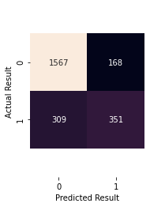

```python
prediction_log = logmodel.predict(X_test2)
matrix_log = confusion_matrix(y_test2, prediction_log)
sns.heatmap(matrix_log, fmt='g', square=True, annot=True, cbar=False)
plt.xlabel("Predicted Result")
plt.ylabel("Actual Result")
a, b = plt.ylim()
a += 0.5
b -= 0.5
plt.ylim(a, b)
plt.show()
```

```python
print("Accuracy:",metrics.accuracy_score(y_test2, prediction_log))
print("Precision:",metrics.precision_score(y_test2, prediction_log))
print("balanced accuracy:",metrics.balanced_accuracy_score(y_test2, prediction_log))
print("Sensitivity:",metrics.recall_score(y_test2, prediction_log))
```

```
Accuracy: 0.8008350730688936
Precision: 0.6763005780346821
balanced accuracy: 0.7174941053183128
Sensitivity: 0.5318181818181819
```

```python
tn, fp, fn, tp = confusion_matrix(prediction_log, y_test2).ravel()
print("Specificity: {:.4f}".format(tn/(tn+fp)))
```

```
Specificity: 0.8353
```

R: The purpose is to test the effectiveness of the model. According to the results below, the training set accuracy and test set accuracy are pretty similar, so we can say that the model is reliable.

```python
print('Training set accuracy:',logmodel.score(X_train2, y_train2))
print('Test set accuracy:',logmodel.score(X_test2, y_test2))
```

```
Training set accuracy: 0.7997772208298524
Test set accuracy: 0.8008350730688936
```

S:

```python
teleusers_new2.columns
```

```
Index(['tenure', 'MonthlyCharges', 'Contract', 'PaymentMethod',
       'OnlineSecurity', 'TechSupport', 'OnlineBackup', 'gender',
       'DeviceProtection', 'MultipleLines', 'PaperlessBilling'],
      dtype='object')
```

```python
emmali_lg=pd.DataFrame([{'gender':1,
                    'tenure':28,
                    'MultipleLines':1,
                    'OnlineSecurity':2,
                    'OnlineBackup':1,
                    'DeviceProtection':1,
                    'TechSupport':0,
                    'Contract':2,
                    'PaperlessBilling':1,
                    'PaymentMethod':1,
                    'MonthlyCharges':53.44,
                    }])
emmali_lg
```

|  | gender | tenure | MultipleLines | OnlineSecurity | OnlineBackup | DeviceProtection | TechSupport | Contract | PaperlessBilling | PaymentMethod | MonthlyCharges |
| --- | --- | --- | --- | --- | --- | --- | --- | --- | --- | --- | --- |
| 0 | 1 | 28 | 1 | 2 | 1 | 1 | 0 | 2 | 1 | 1 | 53.44 |

```python
predictlg_emmali = logmodel.predict(emmali_lg)
print(predictlg_emmali)
logmodel.predict_proba(emmali_lg).round(2)
```

```
[1]
```

```
array([[0., 1.]])
```

The logistic model shows that Emma will churn, the possibility is almost 100%.

T: The weirdo‘s prediction is unreasonable.The possibility cannot be 100%. If the inout is unreasonable, the result cannot be reasonable.

```python
weirdo_lg=pd.DataFrame([{'gender':0,
                    'tenure':228,
                    'MultipleLines':1,
                    'OnlineSecurity':0,
                    'OnlineBackup':0,
                    'DeviceProtection':1,
                    'TechSupport':0,
                    'Contract':2,
                    'PaperlessBilling':0,
                    'PaymentMethod':0,
                    'MonthlyCharges':1000,
                    }])
weirdo_lg
```

|  | gender | tenure | MultipleLines | OnlineSecurity | OnlineBackup | DeviceProtection | TechSupport | Contract | PaperlessBilling | PaymentMethod | MonthlyCharges |
| --- | --- | --- | --- | --- | --- | --- | --- | --- | --- | --- | --- |
| 0 | 0 | 228 | 1 | 0 | 0 | 1 | 0 | 2 | 0 | 0 | 1000 |

```python
predictlg_weirdo = logmodel.predict(weirdo_lg)
print(predictlg_weirdo)
logmodel.predict_proba(weirdo_lg).round(2)
```

```
[1]
```

```
array([[0., 1.]])
```

U:The "churn" variable is really useful. The company marketing team could use this dataframe to predict if the customer will churn.If certain type of customer, for example young female,high monthly charges,use credit card,like paperlessbilling,is predicted by the model that it's more likely to churn. The company strategy team should adjust there marketing strategies, for instance, give them more targeted promotion plans, invest more money on the feminisim related ads.